River A. Watson

## Hierarchical Data

**Data from: Intrasexual competition underlies sexual selection on male breeding coloration in the orangethroat darter, *Etheostoma spectabile* (Zhou & Fuller 2016)**

**Male chromatic measurements taken from photographs of each individual. Colors of red, green, and blue were recorded on the cheek, branchiostegal rays, blue in the first dorsal fin, red in the first dorsal fin, blue in the second dorsal fin, red in the second dorsal fin, blue in the anal fin, lateral bar, caudal peduncle spot, and abdomen (10 measurements in total). Each were measured three times per individual.**

**For the sake of this analysis, all measurements were combined into one score**

**Males are categorized as either a “guarder” or a “sneaker” by if they are the first male to breed with a female (guarder) or if they are second+ to breed with the female (sneaker)**

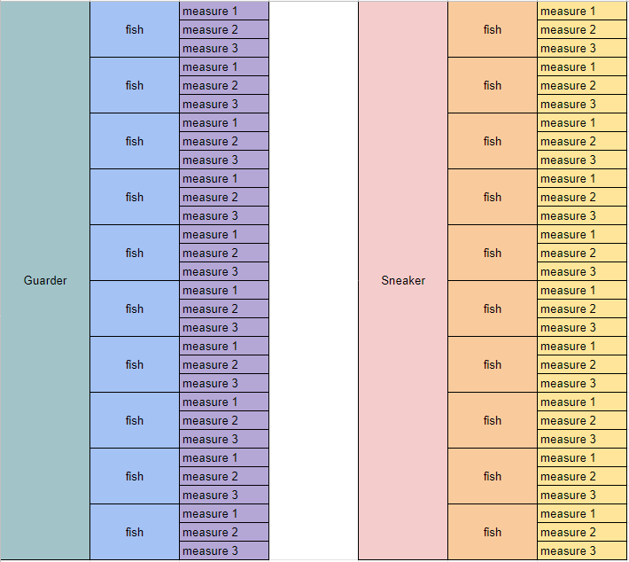

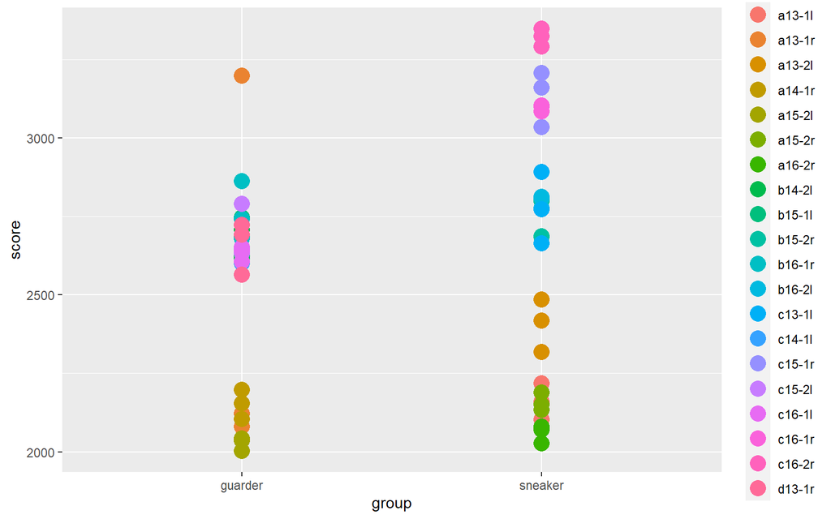

```r
ggplot(color.data2, aes(group, score, colour = fishid)) +
  geom_point(size=5)
```

Not the trend you would expect to see based on the papers results

run linear mixed model

```r
fish.model1 <- lmer(score ~ group + (1|fishid), data = color.data2)

summary(fish.model1)
```

```
## Linear mixed model fit by REML. t-tests use Satterthwaite's method [
## lmerModLmerTest]
## Formula: score ~ group + (1 | fishid)
##    Data: color.data2
##
## REML criterion at convergence: 806.1
##
## Scaled residuals:
##     Min      1Q  Median      3Q     Max
## -2.5412 -0.2312 -0.0459  0.2273  4.7362
##
## Random effects:
##  Groups   Name        Variance Std.Dev.
##  fishid   (Intercept) 123903   352.0
##  Residual              23601   153.6
## Number of obs: 60, groups:  fishid, 20
##
## Fixed effects:
##              Estimate Std. Error     df t value Pr(>|t|)
## (Intercept)    2534.3      114.8   18.0  22.077 1.74e-14 ***
## groupsneaker    128.5      162.3   18.0   0.792    0.439
## ---
## Signif. codes:  0 '***' 0.001 '**' 0.01 '*' 0.05 '.' 0.1 ' ' 1
##
## Correlation of Fixed Effects:
##             (Intr)
## groupsneakr -0.707
```

No significant difference between groups

```r
fish.model2 <- lmer(score ~ (1|group/fishid), data = color.data2)
```

```
## boundary (singular) fit: see ?isSingular
```

```r
summary(fish.model2)
```

```
## Linear mixed model fit by REML. t-tests use Satterthwaite's method [
## lmerModLmerTest]
## Formula: score ~ (1 | group/fishid)
##    Data: color.data2
##
## REML criterion at convergence: 818.8
##
## Scaled residuals:
##     Min      1Q  Median      3Q     Max
## -2.5672 -0.2264 -0.0650  0.2385  4.7102
##
## Random effects:
##  Groups       Name        Variance  Std.Dev.
##  fishid:group (Intercept) 1.213e+05 348.30356
##  group        (Intercept) 1.252e-04   0.01119
##  Residual                 2.360e+04 153.62771
## Number of obs: 60, groups:  fishid:group, 20; group, 2
##
## Fixed effects:
##             Estimate Std. Error      df t value Pr(>|t|)
## (Intercept)  2598.57      80.37   19.00   32.33   <2e-16 ***
## ---
## Signif. codes:  0 '***' 0.001 '**' 0.01 '*' 0.05 '.' 0.1 ' ' 1
## optimizer (nloptwrap) convergence code: 0 (OK)
## boundary (singular) fit: see ?isSingular
```

intercept of 2598.57 is is the mean score

```r
anova(fish.model1,fish.model2, test = "Chisq")
```

```
## refitting model(s) with ML (instead of REML)
```

```
## Data: color.data2
## Models:
## fish.model1: score ~ group + (1 | fishid)
## fish.model2: score ~ (1 | group/fishid)
##             npar    AIC    BIC  logLik deviance Chisq Df Pr(>Chisq)
## fish.model1    4 836.68 845.05 -414.34   828.68
## fish.model2    4 837.36 845.74 -414.68   829.36     0  0
```

Which model does a better job/has lower deviance? They’re about the same.

## Repeated Measures

**Measuring seasonal variation in average home range extent (KUD) of *Plectropomus leopardus*, with 34 individuals**

**Data from: Latitudinal and seasonal variation in space use by a large, predatory reef fish, *Plectropomus leopardus* (Scott et al. 2018)**

[figure not shown]

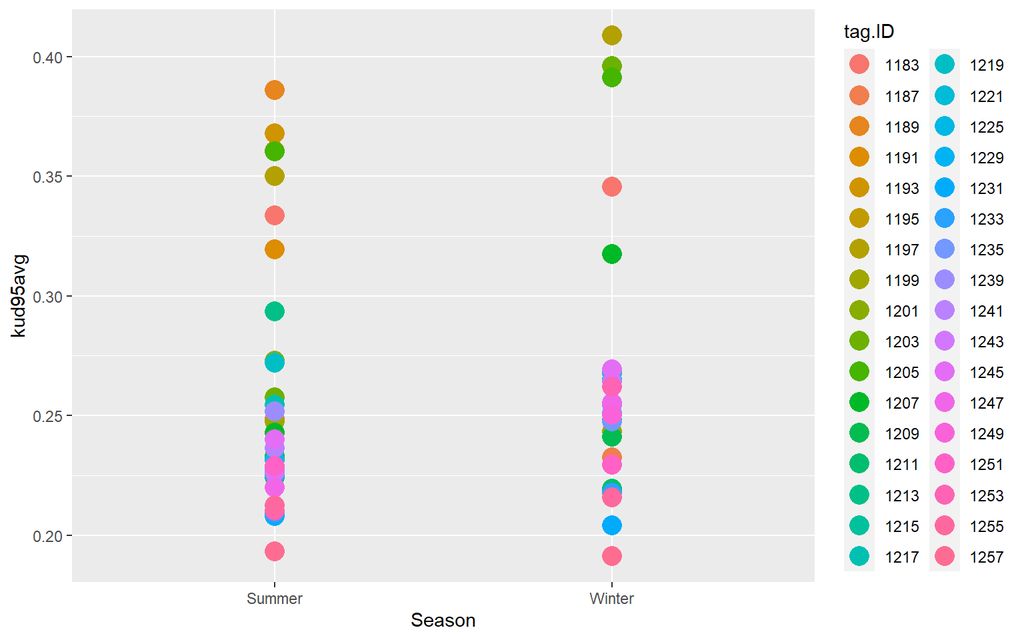

```r
ggplot(kud.data2, aes(Season, kud95avg, colour = tag.ID)) +
  geom_point(size=5)
```

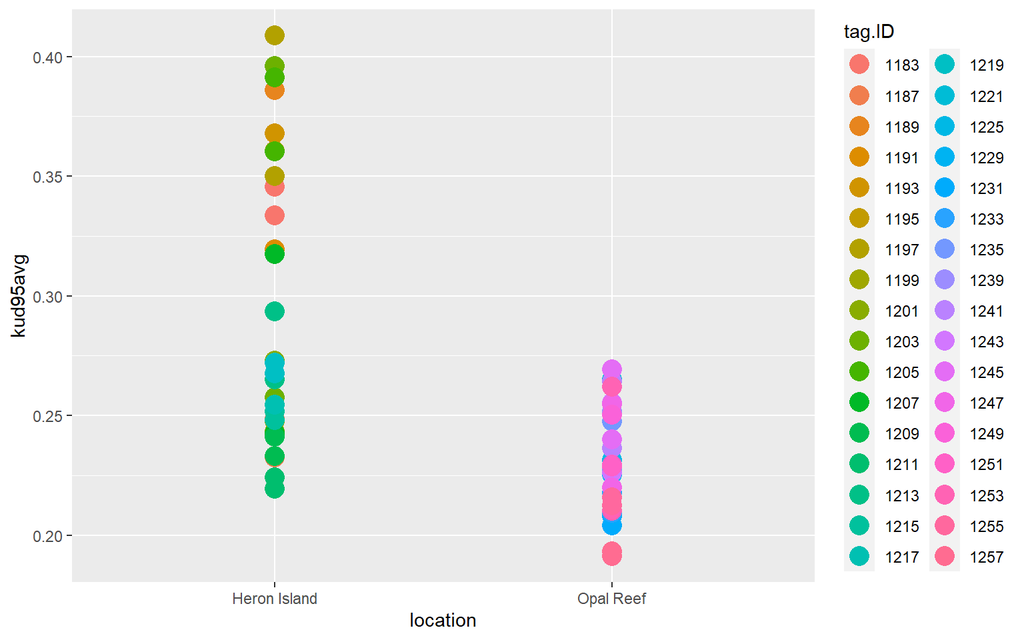

```r
ggplot(kud.data2, aes(location, kud95avg, colour = tag.ID)) +
  geom_point(size=5)
```

```r
kud.model <- lmer(kud95avg~location*Season+(1|tag.ID), data = kud.data2)
#Season is our fixed effect
```

```r
summary(kud.model)
```

```
## Linear mixed model fit by REML. t-tests use Satterthwaite's method [
## lmerModLmerTest]
## Formula: kud95avg ~ location * Season + (1 | tag.ID)
##    Data: kud.data2
##
## REML criterion at convergence: -201.2
##
## Scaled residuals:
##      Min       1Q   Median       3Q      Max
## -2.40782 -0.38895  0.03819  0.30863  2.74861
##
## Random effects:
##  Groups   Name        Variance  Std.Dev.
##  tag.ID   (Intercept) 0.0015529 0.03941
##  Residual             0.0005729 0.02394
## Number of obs: 62, groups:  tag.ID, 34
##
## Fixed effects:
##                                 Estimate Std. Error        df t value Pr(>|t|)
## (Intercept)                     0.293126   0.010867 38.579151  26.973  < 2e-16
## locationOpal Reef              -0.069528   0.015842 38.579151  -4.389 8.56e-05
## SeasonWinter                    0.015098   0.009211 26.446082   1.639    0.113
## locationOpal Reef:SeasonWinter  0.004554   0.012672 25.748276   0.359    0.722
##
## (Intercept)                    ***
## locationOpal Reef              ***
## SeasonWinter
## locationOpal Reef:SeasonWinter
## ---
## Signif. codes:  0 '***' 0.001 '**' 0.01 '*' 0.05 '.' 0.1 ' ' 1
##
## Correlation of Fixed Effects:
##             (Intr) lctnOR SsnWnt
## locatnOplRf -0.686
## SeasonWintr -0.318  0.218
## lctnORf:SsW  0.231 -0.337 -0.727
```

Not a significant difference between seasons.

Using emmeans for comparisons

```r
kud_emm <- emmeans(kud.model, "Season", "location")
kud_emm
```

```
## location = Heron Island:
##  Season emmean     SE   df lower.CL upper.CL
##  Summer  0.293 0.0109 39.9    0.271    0.315
##  Winter  0.308 0.0118 48.4    0.284    0.332
##
## location = Opal Reef:
##  Season emmean     SE   df lower.CL upper.CL
##  Summer  0.224 0.0115 39.9    0.200    0.247
##  Winter  0.243 0.0117 41.6    0.220    0.267
##
## Degrees-of-freedom method: kenward-roger
## Confidence level used: 0.95
```

```r
data_emm <- as.data.frame(summary(kud_emm))
data_emm
```

```
##   Season     location    emmean         SE       df  lower.CL  upper.CL
## 1 Summer Heron Island 0.2931264 0.01086737 39.90677 0.2711611 0.3150918
## 2 Winter Heron Island 0.3082242 0.01183234 48.41722 0.2844390 0.3320095
## 3 Summer    Opal Reef 0.2235982 0.01152658 39.90677 0.2003004 0.2468960
## 4 Winter    Opal Reef 0.2432500 0.01171040 41.59369 0.2196106 0.2668894
```

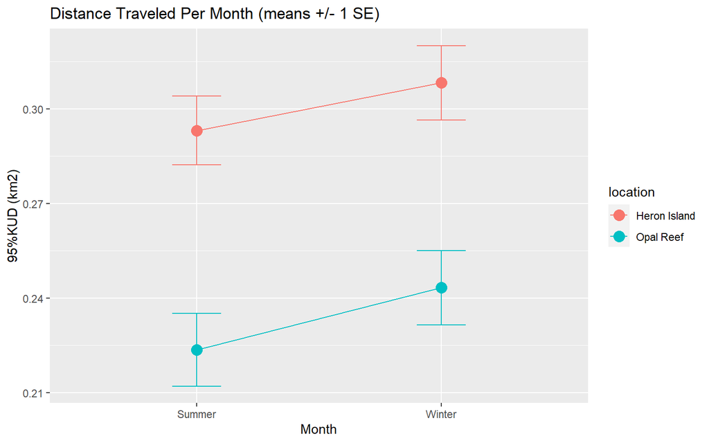

```r
ggplot(data_emm, aes(x=Season, y=emmean, group=location, color=location)) +
  geom_line() +
  geom_point(size=4)+
  geom_errorbar(aes(ymin=emmean-SE, ymax=emmean+SE), width=.2)+
  labs(title="Distance Traveled Per Month (means +/- 1 SE)", x="Month", y = "95%KUD (km2)")
```

```r
#between group contrasts
pairs(emmeans(kud.model, "location", "Season"))
```

```
## Season = Summer:
##  contrast                 estimate     SE   df t.ratio p.value
##  Heron Island - Opal Reef   0.0695 0.0158 39.9   4.389  0.0001
##
## Season = Winter:
##  contrast                 estimate     SE   df t.ratio p.value
##  Heron Island - Opal Reef   0.0650 0.0166 45.1   3.903  0.0003
##
## Degrees-of-freedom method: kenward-roger
```

[output not shown]

[figure not shown]

```r
#within group contrasts
pairs(emmeans(kud.model, "Season", "location"))
```